# Temperatura JP x CG

```r
climas = read_csv(here::here("data/clima_cg_jp-semanal.csv"),
                  col_types = "cTdddddd")

glimpse(climas)
```

```
## Observations: 2,748
## Variables: 8
## $ cidade <chr> "Campina Grande", "Campina Grande", "Campina Grande", "Ca…
## $ semana <dttm> 1992-12-27, 1993-01-03, 1993-01-10, 1993-01-31, 1993-02-…
## $ tmedia <dbl> 26.13333, 26.11905, 25.76667, 25.74000, 26.31429, 26.2857…
## $ tmax   <dbl> 30.4, 32.4, 32.2, 32.0, 32.7, 32.7, 32.3, 32.3, 32.1, 31.…
## $ tmin   <dbl> 20.7, 19.3, 19.7, 19.9, 19.6, 20.0, 20.4, 21.2, 19.0, 19.…
## $ chuva  <dbl> 0.0, 0.0, 0.0, 0.4, 0.3, 0.0, 4.9, 0.0, 0.0, 6.1, 0.4, 1.…
## $ mes    <dbl> 12, 1, 1, 1, 2, 2, 2, 2, 10, 11, 11, 11, 11, 12, 12, 12, …
## $ ano    <dbl> 1992, 1993, 1993, 1993, 1993, 1993, 1993, 1993, 1993, 199…
```

## Temperatura

### Quais os meses mais quentes e mais frios?

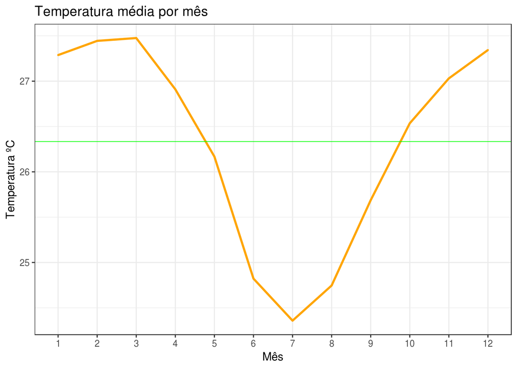

```r
climas %>%
    group_by(mes) %>%
    summarise(tmes = mean(tmedia)) %>%
    ggplot(aes(x = factor(mes), y = tmes, group=1)) +
    geom_line(size = 1, color="orange")+
    geom_point(size = 0.2, color="orange")+
    geom_hline(size=0.3, col="green", aes(yintercept=mean(climas$tmedia))) +
    xlab("Mês") + ylab("Temperatura ºC") +
    ggtitle("Temperatura média por mês")
```

### Qual foi o São João mais frio de CG que está nos nossos dados?

O gráfico de pontos exibe os 10 anos que tiveram o são joão mais frio em campina grande. Para estimar o são joão mais frio de cada ano usamos a média das temperaturas registradas para o mês de junho. Os anos onde o são joão foram mais frios são 2004, 2008 e 2005.

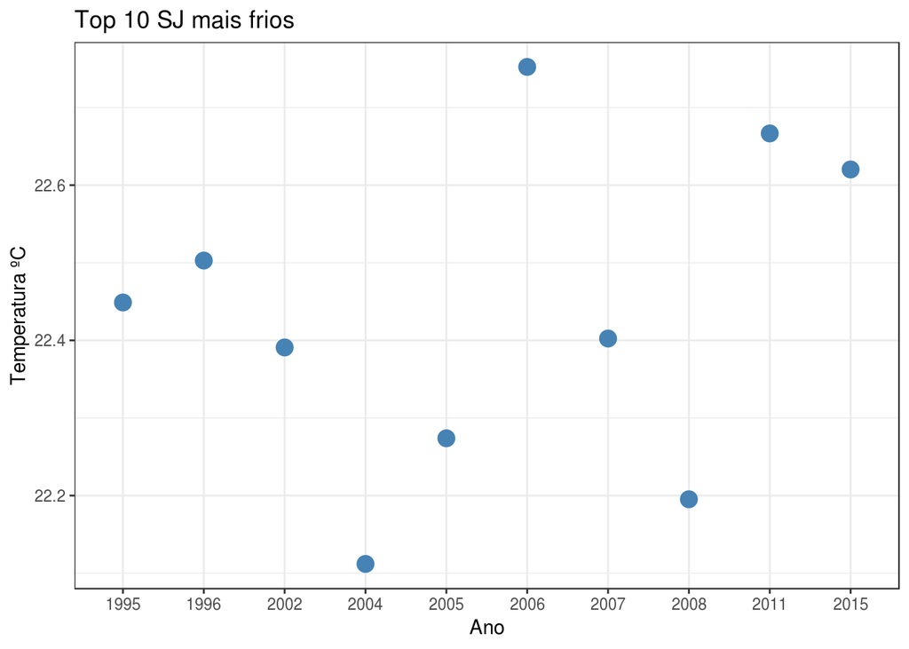

```r
climas %>%
    filter(cidade == "Campina Grande") %>%
    filter(mes == 6) %>%
    group_by(ano) %>%
    summarise(tmes = mean(tmedia)) %>%
    top_n(n = -10, wt = tmes) %>%
    ggplot(aes(x = factor(ano), y = tmes), group=1) +
    geom_point(size=4, color="steelblue") +
    xlab("Ano") + ylab("Temperatura ºC") +
    ggtitle("Top 10 SJ mais frios")
```

Outro fato interessante é que os são joões mais frios 2004, 2008 e 2005 também aparecem no top 7 dos mais chuvosos.

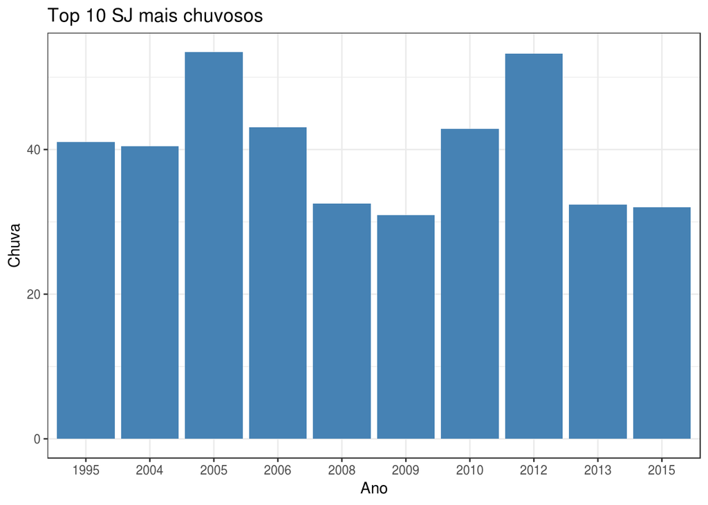

```r
climas %>%
    filter(cidade == "Campina Grande") %>%
    filter(mes == 6) %>%
    group_by(ano) %>%
    summarise(tmes = mean(chuva)) %>%
    top_n(n = 10, wt = tmes) %>%
    ggplot(aes(x = factor(ano), y = tmes)) +
    geom_bar(stat = "identity", fill="steelblue") +
    xlab("Ano") + ylab("Chuva") +
    ggtitle("Top 10 SJ mais chuvosos")
```

Ao estimar a correlação entre temperatura média e chuva para os meses de são joão o resultado é significante. A correlação é negativa isso significa que são joões mais frios também são mais chuvosos.

```r
sj <- climas %>%
        filter(cidade == "Campina Grande") %>%
        filter(mes == 6)

cor(sj$tmedia, sj$chuva)
```

```
## [1] -0.5054541
```

## Chuva

### No geral, onde chove mais?

O gráfico exibe a distribuição das chuvas para as cidades de João Pessoa e Campina Grande. Em João Pessoa chove mais, já que a distribuição da cidade de Campina Grande se concentra mais proximo a zero do que a de João Pessoa.

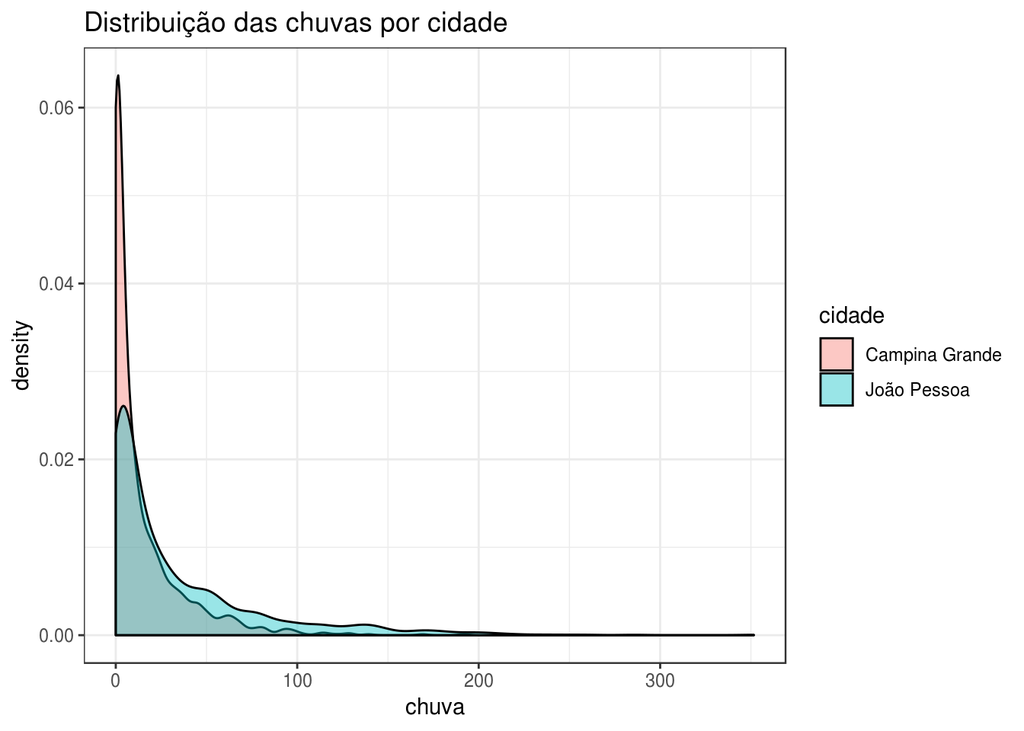

```r
climas %>%
    ggplot(aes(x = chuva, fill = cidade)) +
    geom_density(alpha = .4) +
    ggtitle("Distribuição das chuvas por cidade")
```

### A distribuição é diferente em meses específicos?

O gráfico exibe a distribuição das chuvas para cada estação. É possivel perceber que chove mais durante o inverno e outono, a primavera é o periodo onde chove menos.

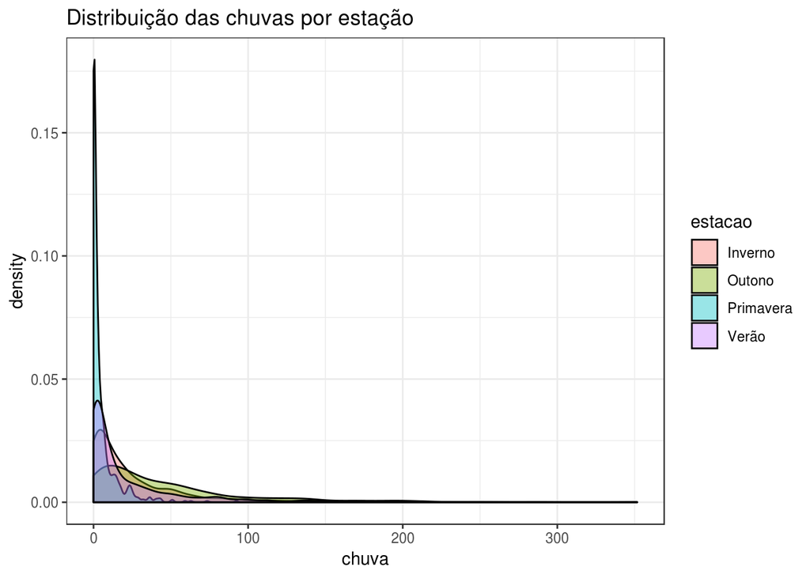

```r
climas %>%
    mutate(estacao = case_when(mes >= 4 & mes <= 6 ~ "Outono",
                               mes >= 7 & mes <= 9 ~ "Inverno",
                               mes >= 10 & mes <= 12 ~ "Primavera",
                               mes >= 1 & mes <= 3 ~ "Verão")) %>%
    ggplot(aes(x = chuva, fill = estacao)) +
    geom_density(alpha = .4) +
    ggtitle("Distribuição das chuvas por estação")
```

Plotanto a chuva média para cada mês fica mais fácil perceber a relação evidenciada pelo gráfico anterior. A linha azul representa a média da chuva considerando todos os meses.

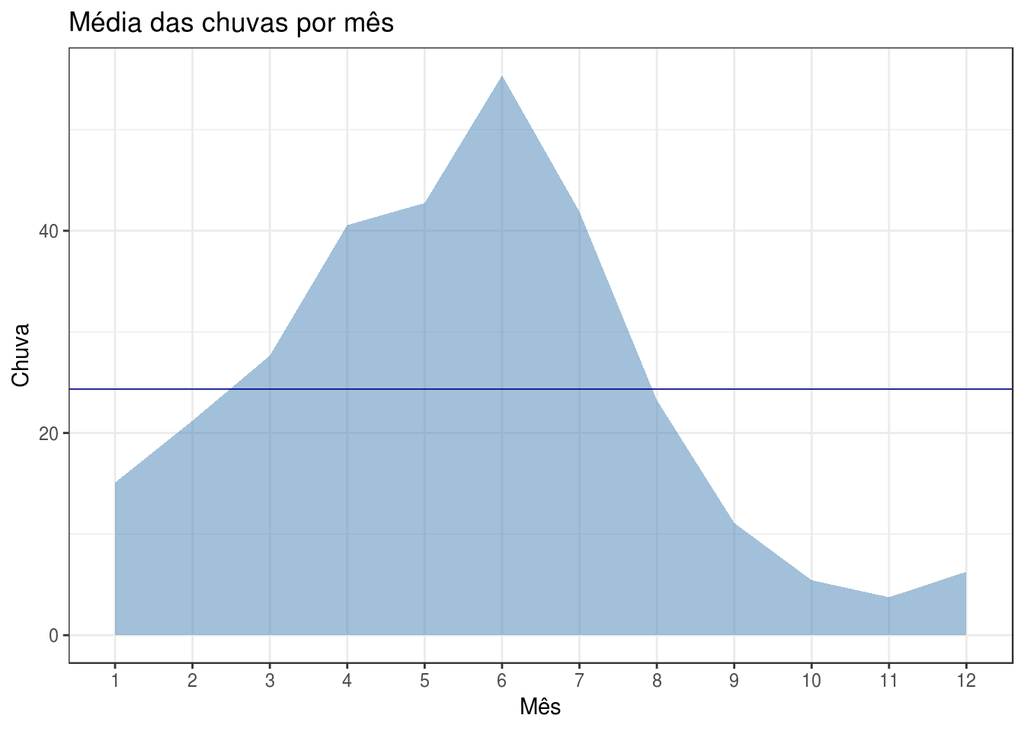

```r
climas %>%
    group_by(mes) %>%
    summarise(cmes = mean(chuva)) %>%
    ggplot(aes(x = factor(mes), y = cmes, group=1)) +
    geom_area(size = 1, fill="steelblue", alpha = 0.5)+
    geom_hline(size=0.3, col="darkblue", aes(yintercept=mean(climas$chuva))) +
    xlab("Mês") + ylab("Chuva") +
    ggtitle("Média das chuvas por mês")
```